# Week Two: Summarizing & Visualizing Numerical Data

Winter 2023

Welcome!

In this week’s coursework we are going to continuing exploring data, through data summaries and visualizations, focusing specifically on **numerical** variables. We will be using the **dplyr** package in `R` to wrangle our data and the **ggplot2** package to created data visualizations.

## 0.1 Learning Outcomes

By the end of this coursework you should be able to:

- outline the differences between numerical and categorical variables
- describe what type of summary statistic is appropriate for a given distribution of a numerical variable
- discuss when it is / is not appropriate to summarize a variable with a mean
- create visualizations of one and two numerical variables
- discuss the benefits and shortcomings of different visualizations

## 0.2 This Week’s TODOs

📖 Reading: 30-45 minutes

💻 Tutorials: 60-75 minutes

✅ Check-ins: 2 (submit on Canvas)

📜 Group Discussion Homework: 3 Questions

# 1 Exploring Numerical Data

## 1.1 📖 Textbook Reading

[figure not shown]

[**Required Reading:** Exploring Numerical Data](https://openintro-ims.netlify.app/explore-numerical.html)

**Tip**

See Canvas for the Week 2 Reading Guides.

## 1.2 ✅ Concept Quiz Questions

1. Suppose we have data on the departure delays of flights flying out of New York. What shape would you expect the distribution of departure delays to have?
- right skew
- left skew
- bimodal
- mutimodal
- uniform

*Hint:* Think about how you would “typically” expect flight delays to behave.

2. To better decide what summary statistic we should use to summarize the departure delays it would be best to create a data visualization of the *distribution* of departure delays.

What type of visualizations could we make? (select all that apply)

- boxplot
- histogram
- barplot
- density plot
- scatterplot

# 2 Visualizing Numerical Data

## 2.1 📖 Textbook Reading

[figure not shown]

[**Required Reading:** Data Visualization](https://moderndive.com/2-viz.html)

**Tip**

See Canvas for the Week 2 Reading Guides.

## 2.2 ✅ Concept Quiz Questions

1. What aesthetics are being used in the following plot?

Hint: Think about what goes inside of the `aes()` function and what does not.

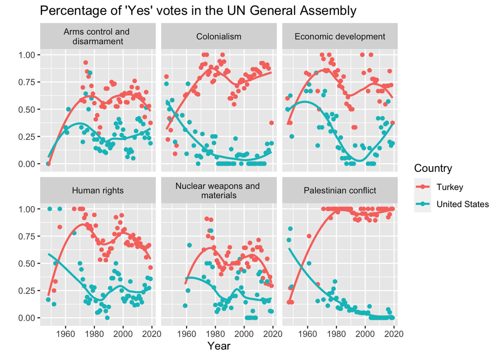

- `x` axis
- `y` axis
- `color`
- `facet`s
- `fill`
- `point`s
- `line`s
2. What geometric objects are being used in the displayed visualization?

Hint: Think about what `geom`s you would use to make this plot!

- points
- lines / smoothers
- colors
- facets
3. What aspects of the distribution of departure delays can you see in the histogram that you could not see in the boxplot?

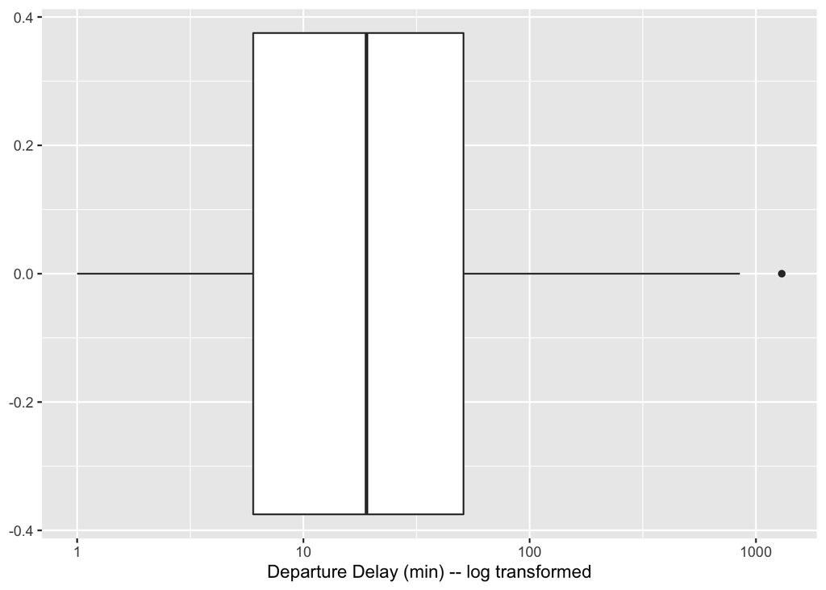

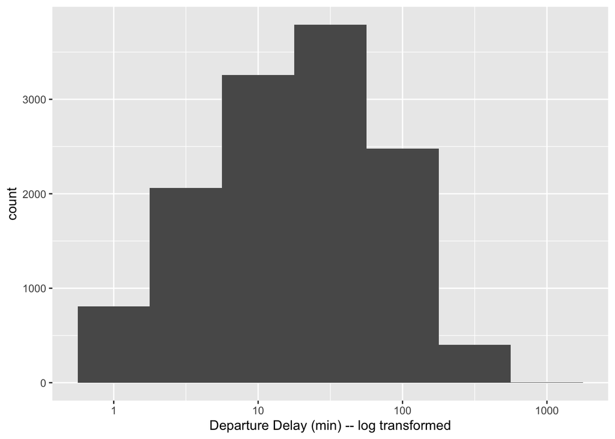

- shape of distribution
- median
- outliers
- mode

### 2.2.1 R Tutorial

💻 [**Required Tutorial:** Exploring Numerical Data](https://openintro.shinyapps.io/ims-02-explore-02/)

💻 [**Required Tutorial:** Summarizing with Statistics](https://openintro.shinyapps.io/ims-02-explore-03/)